# Multiple Regression

#### Between groups

**Application** : Identifying how multiple predictors contribute to linear equation relating the predictors to criterion.  
**Research Hypothesis** : The researcher hypothesized that students own pets may agree more with the statement that Ben should get a haircut.

**First load packages and library**  
> point and click on the folder under the Environment Tab

**Install packages if you have not installed them**

```r
install.packages(c("tidyverse", "lsr", "multcomp","corrplot","lm.beta","rockchalk","Hmisc"))
```

**Load them**

```r
library(tidyverse)
library(lsr)
library(multcomp)
library(corrplot)
library(lm.beta)
library(rockchalk)
library(Hmisc)
```

**Cleaning**  
Data has to be cleaned before analyzing. this is done with the `na.omit` function. Basically this deletes any entries that have missing values. The reason why we do this is because analysis will return errors.  
The cleaned data is stored seperated into a new `data.frame` called `class.clean`

```r
class.clean <-(na.omit(class))
```

**Creating correlational matrix**  
A correlation matrix is usually the first step because it provides information for what things are correlated with other things. `cor` function stands for correlation and we will recode the correlations into a list called `class.cor`.

```r
class.cor <- cor(class.clean)
```

**Creating the matrix**  
We can now push the correlational matrix into a plot using the `corrplot` function from `corrplot` package. There are many ways and methods to predict correlational matrix: including `circles`,`square`, and `number`. We will be using `number`. The `number.cex` arguement allows for the adjusting of font size.  
**Correlation matrix for `class`**

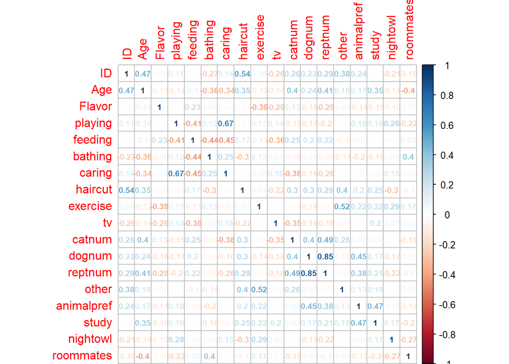

```r
corrplot(class.cor, method = "number", number.cex = .65)
```

Alternatively, `rcorr` function from package `Hmisc` can provide correlational matrixes and P values.

```r
rcorr(as.matrix(class.cor))
```

```
##               ID   Age Flavor playing feeding bathing caring haircut
## ID          1.00  0.71  -0.06   -0.10    0.16   -0.59  -0.13    0.84
## Age         0.71  1.00  -0.12   -0.38    0.38   -0.73  -0.57    0.70
## Flavor     -0.06 -0.12   1.00   -0.07    0.32   -0.11   0.01   -0.05
## playing    -0.10 -0.38  -0.07    1.00   -0.74    0.30   0.89   -0.30
## feeding     0.16  0.38   0.32   -0.74    1.00   -0.62  -0.76    0.35
## bathing    -0.59 -0.73  -0.11    0.30   -0.62    1.00   0.47   -0.66
## caring     -0.13 -0.57   0.01    0.89   -0.76    0.47   1.00   -0.32
## haircut     0.84  0.70  -0.05   -0.30    0.35   -0.66  -0.32    1.00
## exercise   -0.05 -0.19  -0.57    0.14   -0.29    0.17   0.02   -0.05
## tv         -0.51 -0.41  -0.42    0.42   -0.64    0.35   0.43   -0.51
## catnum      0.51  0.71   0.10   -0.57    0.58   -0.49  -0.72    0.57
## dognum      0.42  0.58  -0.22   -0.48    0.43   -0.38  -0.52    0.51
## reptnum     0.48  0.69  -0.31   -0.52    0.45   -0.42  -0.60    0.55
## other       0.53  0.32  -0.19   -0.05   -0.08   -0.32  -0.11    0.54
## animalpref  0.39  0.43  -0.39    0.05   -0.01   -0.43  -0.14    0.40
## study       0.13  0.49  -0.41    0.08   -0.05   -0.43  -0.18    0.30
## nightowl   -0.47 -0.36  -0.15    0.47   -0.22    0.19   0.30   -0.57
## roommates  -0.45 -0.63  -0.03   -0.25   -0.04    0.60   0.01   -0.35
##            exercise    tv catnum dognum reptnum other animalpref study
## ID            -0.05 -0.51   0.51   0.42    0.48  0.53       0.39  0.13
## Age           -0.19 -0.41   0.71   0.58    0.69  0.32       0.43  0.49
## Flavor        -0.57 -0.42   0.10  -0.22   -0.31 -0.19      -0.39 -0.41
## playing        0.14  0.42  -0.57  -0.48   -0.52 -0.05       0.05  0.08
## feeding       -0.29 -0.64   0.58   0.43    0.45 -0.08      -0.01 -0.05
## bathing        0.17  0.35  -0.49  -0.38   -0.42 -0.32      -0.43 -0.43
## caring         0.02  0.43  -0.72  -0.52   -0.60 -0.11      -0.14 -0.18
## haircut       -0.05 -0.51   0.57   0.51    0.55  0.54       0.40  0.30
## exercise       1.00  0.20  -0.14  -0.30   -0.21  0.61       0.16  0.24
## tv             0.20  1.00  -0.71  -0.44   -0.44 -0.16      -0.03  0.21
## catnum        -0.14 -0.71   1.00   0.65    0.72  0.28       0.19  0.10
## dognum        -0.30 -0.44   0.65   1.00    0.97 -0.11       0.59  0.25
## reptnum       -0.21 -0.44   0.72   0.97    1.00 -0.02       0.56  0.30
## other          0.61 -0.16   0.28  -0.11   -0.02  1.00       0.18  0.24
## animalpref     0.16 -0.03   0.19   0.59    0.56  0.18       1.00  0.68
## study          0.24  0.21   0.10   0.25    0.30  0.24       0.68  1.00
## nightowl       0.38  0.30  -0.30  -0.47   -0.47 -0.06      -0.18  0.13
## roommates      0.17  0.14  -0.38  -0.24   -0.27 -0.22      -0.39 -0.51
##            nightowl roommates
## ID            -0.47     -0.45
```

[output cut: 64 more lines]

```
## playing    0.0484   0.3146
## feeding    0.3728   0.8764
## bathing    0.4531   0.0085
## caring     0.2261   0.9601
## haircut    0.0145   0.1485
## exercise   0.1207   0.5110
## tv         0.2258   0.5825
## catnum     0.2278   0.1157
## dognum     0.0469   0.3434
## reptnum    0.0474   0.2786
## other      0.8136   0.3832
## animalpref 0.4789   0.1134
## study      0.5939   0.0316
## nightowl            0.3173
## roommates  0.3173
```

**Correlation Tests**  
That is alot information, quite frankly, we can see that there is a significant correlation between haircuts and pets owned.  
A correlationed test `cor.test` can quickly provide information that is more useful than just looking at a matrix.

```r
cor.test(class.clean$haircut,class.clean$other)
```

```
##
##  Pearson's product-moment correlation
##
## data:  class.clean$haircut and class.clean$other
## t = 2.5412, df = 34, p-value = 0.01578
## alternative hypothesis: true correlation is not equal to 0
## 95 percent confidence interval:
##  0.0817134 0.6435840
## sample estimates:
##       cor
## 0.3995236
```

**Linear Regression**  
Now we want to look at the regression analysis. we are going to store the information into `lin.dat` while using the `lm` function.

```r
lin.dat <- lm(haircut~other, dat = class.clean)
```

**Summary**  
Now that we have the model created, we need to wrap it with `summary` to derive information from it.

```r
summary(lin.dat)
```

```
##
## Call:
## lm(formula = haircut ~ other, data = class.clean)
##
## Residuals:
##     Min      1Q  Median      3Q     Max
## -2.1215 -0.5356 -0.0495  0.8965  1.8065
##
## Coefficients:
##             Estimate Std. Error t value Pr(>|t|)
## (Intercept)  2.97749    0.23129  12.874 1.26e-14 ***
## other        0.07202    0.02834   2.541   0.0158 *
## ---
## Signif. codes:  0 '***' 0.001 '**' 0.01 '*' 0.05 '.' 0.1 ' ' 1
##
## Residual standard error: 1.151 on 34 degrees of freedom
## Multiple R-squared:  0.1596, Adjusted R-squared:  0.1349
## F-statistic: 6.458 on 1 and 34 DF,  p-value: 0.01578
```

**Partial Correlation Coefficient**  
Using the `getPartialCor` function from the `rockchalk` package we can find the correlation coefficients.

```r
getPartialCor(lin.dat)
```

```
##            haircut
## haircut -1.0000000
## x        0.3995236
```

**Multple Regression**  
What if we want to look at the multiple regression analysis with more than one variable? Let’s say we want to use `other` which is other pets with `dognum` which is the number of dogs. We are going to store the information into `mult.dat` while using the `lm` function.

```r
mult.dat <- lm(haircut ~ other + dognum, dat =class.clean)
```

**Summary**  
Now that we have the model created, we need to wrap it with `summary` to derive information from it.

```r
summary(mult.dat)
```

```
##
## Call:
## lm(formula = haircut ~ other + dognum, data = class.clean)
##
## Residuals:
##      Min       1Q   Median       3Q      Max
## -1.97333 -0.61291 -0.05058  0.79069  2.10597
##
## Coefficients:
##             Estimate Std. Error t value Pr(>|t|)
## (Intercept)  2.58400    0.27953   9.244 1.12e-10 ***
## other        0.07725    0.02687   2.875  0.00703 **
## dognum       0.07827    0.03468   2.257  0.03075 *
## ---
## Signif. codes:  0 '***' 0.001 '**' 0.01 '*' 0.05 '.' 0.1 ' ' 1
##
## Residual standard error: 1.088 on 33 degrees of freedom
## Multiple R-squared:  0.272,  Adjusted R-squared:  0.2279
## F-statistic: 6.165 on 2 and 33 DF,  p-value: 0.005311
```

**Information for write up**  
We will need some more information for the write up. **Means and Standard Deviation**  
The command requests that the `sd` or `mean` function be applied to `class$other` and `class$dognum`.

```r
mean(class.clean$other)
```

```
## [1] 4.555556
```

```r
mean(class.clean$dognum)
```

```
## [1] 4.722222
```

```r
sd(class.clean$other)
```

```
## [1] 6.867915
```

```r
sd(class.clean$dognum)
```

```
## [1] 5.321714
```

**Sample size**  
Then we will need to know the sample size per group. This will be accomplished with the `table` function.  
Factor levels for `haircut` because ‘1’ haircut does not make sense. Recode variables into a new variable instead of overwriting the original codes. Now codes like ‘1’ are disagree while ‘5’ is agree.

```r
class.clean$haircut2[class.clean$haircut==1] <- "Disagree"
class.clean$haircut2[class.clean$haircut==2] <- "Disagree"
class.clean$haircut2[class.clean$haircut==3] <- "Neutral"
class.clean$haircut2[class.clean$haircut==4] <- "Agree"
class.clean$haircut2[class.clean$haircut==5] <- "Agree"
```

Now we see that there is good amount of people who aree or disagree…maybe even neutral

```r
table(class.clean$haircut2)
```

```
##
##    Agree Disagree  Neutral
##       17        7       12
```

**Effect size**  
Effect sizes can be found from the `lsr` package utilizing the `etaSquared` function.

```r
etaSquared(mult.dat)
```

```
##           eta.sq eta.sq.part
## other  0.1823073   0.2002696
## dognum 0.1123787   0.1337236
```

**Partial Correlation Coefficient**  
Using the `getPartialCor` function from the `rockchalk` package we can find the correlation coefficients.

```r
getPartialCor(mult.dat)
```

```
##            haircut
## haircut -1.0000000
## other    0.4475149
## dognum   0.3656823
```

**Beta Weights**  
Finding the beta weights for information is important. We can use the `lm.beta` function from `lm.beta` package.

```r
lm.beta(mult.dat)
```

```
##
## Call:
## lm(formula = haircut ~ other + dognum, data = class.clean)
##
## Standardized Coefficients::
## (Intercept)       other      dognum
##   0.0000000   0.4285750   0.3364858
```

[output not shown]

[output not shown]

| Table 3 |  |  |
| --- | --- | --- |
| Correlation and weights |  |  |
| Variable | *r* | B |
| Others | .44* | .42* |
| Dogs | .36* | .33* |

*p< .05